# Project: Investigate a Dataset - [TMDb movie data]

- Introduction
- Data Wrangling
- Exploratory Data Analysis
- Conclusions

## Introduction

### Dataset Description

> This data set contains information about 10,000 movies collected from The Movie Database (TMDb), including user ratings and revenue. Certain columns, like ‘cast’and ‘genres’, contain multiple values separated by pipe (|) characters.There are some odd characters in the ‘cast’ column. Don’t worry about cleaning them. You can leave them as is. The final two columns ending with “_adj” show the budget and revenue of the associated movie in terms of 2010 dollars, accounting for inflation over time.

### Question(s) for Analysis

What is the mean and distribution of vote average?

Which moviehas the shortest/longest runtime?

Which year has the most movies released?

Which movie has the highest/lowest profit?

Most Frequent movie director?

What is production company with the most profit?

Does the production company affects on movie's popularity?

Which genres are most popular from year to year?

The relationship between vote average and revenue

The relationship between vote average and budget

```python
#Importing necessary libraries
import pandas as pd
import numpy as np
import matplotlib.pyplot as plt
import seaborn as sns
% matplotlib inline
```

```python
# Upgrade pandas to use dataframe.explode() function.
!pip install --upgrade pandas==0.25.0
```

## Data Wrangling

Load the data, observe it, and see what rows and columns need cleaning.

```python
#load importnat liberaries
import pandas as pd
import numpy as np
import matplotlib.pyplot as plt
import seaborn as sns
```

```python
#load the data
df=pd.read_csv('Database_TMDb_movie_data/tmdb-movies.csv')
df.head()
```

|  | id | imdb_id | popularity | budget | revenue | original_title | cast | homepage | director | tagline | ... | overview | runtime | genres | production_companies | release_date | vote_count | vote_average | release_year | budget_adj | revenue_adj |
| --- | --- | --- | --- | --- | --- | --- | --- | --- | --- | --- | --- | --- | --- | --- | --- | --- | --- | --- | --- | --- | --- |
| 0 | 135397 | tt0369610 | 32.985763 | 150000000 | 1513528810 | Jurassic World | Chris Pratt\|Bryce Dallas Howard\|Irrfan Khan\|Vi... | http://www.jurassicworld.com/ | Colin Trevorrow | The park is open. | ... | Twenty-two years after the events of Jurassic ... | 124 | Action\|Adventure\|Science Fiction\|Thriller | Universal Studios\|Amblin Entertainment\|Legenda... | 6/9/15 | 5562 | 6.5 | 2015 | 1.379999e+08 | 1.392446e+09 |
| 1 | 76341 | tt1392190 | 28.419936 | 150000000 | 378436354 | Mad Max: Fury Road | Tom Hardy\|Charlize Theron\|Hugh Keays-Byrne\|Nic... | http://www.madmaxmovie.com/ | George Miller | What a Lovely Day. | ... | An apocalyptic story set in the furthest reach... | 120 | Action\|Adventure\|Science Fiction\|Thriller | Village Roadshow Pictures\|Kennedy Miller Produ... | 5/13/15 | 6185 | 7.1 | 2015 | 1.379999e+08 | 3.481613e+08 |
| 2 | 262500 | tt2908446 | 13.112507 | 110000000 | 295238201 | Insurgent | Shailene Woodley\|Theo James\|Kate Winslet\|Ansel... | http://www.thedivergentseries.movie/#insurgent | Robert Schwentke | One Choice Can Destroy You | ... | Beatrice Prior must confront her inner demons ... | 119 | Adventure\|Science Fiction\|Thriller | Summit Entertainment\|Mandeville Films\|Red Wago... | 3/18/15 | 2480 | 6.3 | 2015 | 1.012000e+08 | 2.716190e+08 |
| 3 | 140607 | tt2488496 | 11.173104 | 200000000 | 2068178225 | Star Wars: The Force Awakens | Harrison Ford\|Mark Hamill\|Carrie Fisher\|Adam D... | http://www.starwars.com/films/star-wars-episod... | J.J. Abrams | Every generation has a story. | ... | Thirty years after defeating the Galactic Empi... | 136 | Action\|Adventure\|Science Fiction\|Fantasy | Lucasfilm\|Truenorth Productions\|Bad Robot | 12/15/15 | 5292 | 7.5 | 2015 | 1.839999e+08 | 1.902723e+09 |
| 4 | 168259 | tt2820852 | 9.335014 | 190000000 | 1506249360 | Furious 7 | Vin Diesel\|Paul Walker\|Jason Statham\|Michelle ... | http://www.furious7.com/ | James Wan | Vengeance Hits Home | ... | Deckard Shaw seeks revenge against Dominic Tor... | 137 | Action\|Crime\|Thriller | Universal Pictures\|Original Film\|Media Rights ... | 4/1/15 | 2947 | 7.3 | 2015 | 1.747999e+08 | 1.385749e+09 |

5 rows × 21 columns

```python
#show some information about data and data types
df.info()
```

```
<class 'pandas.core.frame.DataFrame'>
RangeIndex: 10866 entries, 0 to 10865
Data columns (total 21 columns):
id                      10866 non-null int64
imdb_id                 10856 non-null object
popularity              10866 non-null float64
budget                  10866 non-null int64
revenue                 10866 non-null int64
original_title          10866 non-null object
cast                    10790 non-null object
homepage                2936 non-null object
director                10822 non-null object
tagline                 8042 non-null object
keywords                9373 non-null object
overview                10862 non-null object
runtime                 10866 non-null int64
genres                  10843 non-null object
production_companies    9836 non-null object
release_date            10866 non-null object
vote_count              10866 non-null int64
vote_average            10866 non-null float64
release_year            10866 non-null int64
budget_adj              10866 non-null float64
revenue_adj             10866 non-null float64
dtypes: float64(4), int64(6), object(11)
memory usage: 1.7+ MB
```

It appears there are some null values need to be fixed and there are some unneeded columns needs to be dropped.

```python
#see summary statistics about aur data
df.describe()
```

|  | id | popularity | budget | revenue | runtime | vote_count | vote_average | release_year | budget_adj | revenue_adj |
| --- | --- | --- | --- | --- | --- | --- | --- | --- | --- | --- |
| count | 10866.000000 | 10866.000000 | 1.086600e+04 | 1.086600e+04 | 10866.000000 | 10866.000000 | 10866.000000 | 10866.000000 | 1.086600e+04 | 1.086600e+04 |
| mean | 66064.177434 | 0.646441 | 1.462570e+07 | 3.982332e+07 | 102.070863 | 217.389748 | 5.974922 | 2001.322658 | 1.755104e+07 | 5.136436e+07 |
| std | 92130.136561 | 1.000185 | 3.091321e+07 | 1.170035e+08 | 31.381405 | 575.619058 | 0.935142 | 12.812941 | 3.430616e+07 | 1.446325e+08 |
| min | 5.000000 | 0.000065 | 0.000000e+00 | 0.000000e+00 | 0.000000 | 10.000000 | 1.500000 | 1960.000000 | 0.000000e+00 | 0.000000e+00 |
| 25% | 10596.250000 | 0.207583 | 0.000000e+00 | 0.000000e+00 | 90.000000 | 17.000000 | 5.400000 | 1995.000000 | 0.000000e+00 | 0.000000e+00 |
| 50% | 20669.000000 | 0.383856 | 0.000000e+00 | 0.000000e+00 | 99.000000 | 38.000000 | 6.000000 | 2006.000000 | 0.000000e+00 | 0.000000e+00 |
| 75% | 75610.000000 | 0.713817 | 1.500000e+07 | 2.400000e+07 | 111.000000 | 145.750000 | 6.600000 | 2011.000000 | 2.085325e+07 | 3.369710e+07 |
| max | 417859.000000 | 32.985763 | 4.250000e+08 | 2.781506e+09 | 900.000000 | 9767.000000 | 9.200000 | 2015.000000 | 4.250000e+08 | 2.827124e+09 |

### Data Cleaning

##### in this section we gonna clean our data like drop duplicates, deal with null values,...etc

```python
#Check duplicates
df.duplicated().sum()
```

```
1
```

It seems that there is one duplicate value, let's drop it.

```python
#Drop the duplicated rows
df.drop_duplicates(inplace=True)
#Check the duplicates again
df.duplicated().sum()
```

```
0
```

Problem solved!

```python
#drop unneeded columns
df.drop(columns=['imdb_id','budget','revenue','homepage','tagline','keywords','overview','release_date'],axis=1,inplace=True)
df.head()
```

|  | id | popularity | original_title | cast | director | runtime | genres | production_companies | vote_count | vote_average | release_year | budget_adj | revenue_adj |
| --- | --- | --- | --- | --- | --- | --- | --- | --- | --- | --- | --- | --- | --- |
| 0 | 135397 | 32.985763 | Jurassic World | Chris Pratt\|Bryce Dallas Howard\|Irrfan Khan\|Vi... | Colin Trevorrow | 124 | Action\|Adventure\|Science Fiction\|Thriller | Universal Studios\|Amblin Entertainment\|Legenda... | 5562 | 6.5 | 2015 | 1.379999e+08 | 1.392446e+09 |
| 1 | 76341 | 28.419936 | Mad Max: Fury Road | Tom Hardy\|Charlize Theron\|Hugh Keays-Byrne\|Nic... | George Miller | 120 | Action\|Adventure\|Science Fiction\|Thriller | Village Roadshow Pictures\|Kennedy Miller Produ... | 6185 | 7.1 | 2015 | 1.379999e+08 | 3.481613e+08 |
| 2 | 262500 | 13.112507 | Insurgent | Shailene Woodley\|Theo James\|Kate Winslet\|Ansel... | Robert Schwentke | 119 | Adventure\|Science Fiction\|Thriller | Summit Entertainment\|Mandeville Films\|Red Wago... | 2480 | 6.3 | 2015 | 1.012000e+08 | 2.716190e+08 |
| 3 | 140607 | 11.173104 | Star Wars: The Force Awakens | Harrison Ford\|Mark Hamill\|Carrie Fisher\|Adam D... | J.J. Abrams | 136 | Action\|Adventure\|Science Fiction\|Fantasy | Lucasfilm\|Truenorth Productions\|Bad Robot | 5292 | 7.5 | 2015 | 1.839999e+08 | 1.902723e+09 |
| 4 | 168259 | 9.335014 | Furious 7 | Vin Diesel\|Paul Walker\|Jason Statham\|Michelle ... | James Wan | 137 | Action\|Crime\|Thriller | Universal Pictures\|Original Film\|Media Rights ... | 2947 | 7.3 | 2015 | 1.747999e+08 | 1.385749e+09 |

```python
#rename budget_adj and revenue_adj to be budget and revenue
df.rename(columns={'budget_adj':'budget',"revenue_adj":'revenue'},inplace=True)
df.head()
```

|  | id | popularity | original_title | cast | director | runtime | genres | production_companies | vote_count | vote_average | release_year | budget | revenue |
| --- | --- | --- | --- | --- | --- | --- | --- | --- | --- | --- | --- | --- | --- |
| 0 | 135397 | 32.985763 | Jurassic World | Chris Pratt\|Bryce Dallas Howard\|Irrfan Khan\|Vi... | Colin Trevorrow | 124 | Action\|Adventure\|Science Fiction\|Thriller | Universal Studios\|Amblin Entertainment\|Legenda... | 5562 | 6.5 | 2015 | 1.379999e+08 | 1.392446e+09 |
| 1 | 76341 | 28.419936 | Mad Max: Fury Road | Tom Hardy\|Charlize Theron\|Hugh Keays-Byrne\|Nic... | George Miller | 120 | Action\|Adventure\|Science Fiction\|Thriller | Village Roadshow Pictures\|Kennedy Miller Produ... | 6185 | 7.1 | 2015 | 1.379999e+08 | 3.481613e+08 |
| 2 | 262500 | 13.112507 | Insurgent | Shailene Woodley\|Theo James\|Kate Winslet\|Ansel... | Robert Schwentke | 119 | Adventure\|Science Fiction\|Thriller | Summit Entertainment\|Mandeville Films\|Red Wago... | 2480 | 6.3 | 2015 | 1.012000e+08 | 2.716190e+08 |
| 3 | 140607 | 11.173104 | Star Wars: The Force Awakens | Harrison Ford\|Mark Hamill\|Carrie Fisher\|Adam D... | J.J. Abrams | 136 | Action\|Adventure\|Science Fiction\|Fantasy | Lucasfilm\|Truenorth Productions\|Bad Robot | 5292 | 7.5 | 2015 | 1.839999e+08 | 1.902723e+09 |
| 4 | 168259 | 9.335014 | Furious 7 | Vin Diesel\|Paul Walker\|Jason Statham\|Michelle ... | James Wan | 137 | Action\|Crime\|Thriller | Universal Pictures\|Original Film\|Media Rights ... | 2947 | 7.3 | 2015 | 1.747999e+08 | 1.385749e+09 |

###### check the null value

```python
df.info()
```

```
<class 'pandas.core.frame.DataFrame'>
Int64Index: 10865 entries, 0 to 10865
Data columns (total 13 columns):
id                      10865 non-null int64
popularity              10865 non-null float64
original_title          10865 non-null object
cast                    10789 non-null object
director                10821 non-null object
runtime                 10865 non-null int64
genres                  10842 non-null object
production_companies    9835 non-null object
vote_count              10865 non-null int64
vote_average            10865 non-null float64
release_year            10865 non-null int64
budget                  10865 non-null float64
revenue                 10865 non-null float64
dtypes: float64(4), int64(4), object(5)
memory usage: 1.2+ MB
```

Most of null values are strings and we can't fill it so we will drop it.

```python
#drop NaNs
df.dropna(axis=0,inplace=True)
df.info()
```

```
<class 'pandas.core.frame.DataFrame'>
Int64Index: 9772 entries, 0 to 10865
Data columns (total 13 columns):
id                      9772 non-null int64
popularity              9772 non-null float64
original_title          9772 non-null object
cast                    9772 non-null object
director                9772 non-null object
runtime                 9772 non-null int64
genres                  9772 non-null object
production_companies    9772 non-null object
vote_count              9772 non-null int64
vote_average            9772 non-null float64
release_year            9772 non-null int64
budget                  9772 non-null float64
revenue                 9772 non-null float64
dtypes: float64(4), int64(4), object(5)
memory usage: 1.0+ MB
```

Problem Solved!

Cheak if there are null values in diffrent form.

Like if there is runtime equal 0 or negative

```python
df[df['runtime']<=0]
```

|  | id | popularity | original_title | cast | director | runtime | genres | production_companies | vote_count | vote_average | release_year | budget | revenue |
| --- | --- | --- | --- | --- | --- | --- | --- | --- | --- | --- | --- | --- | --- |
| 92 | 370687 | 1.876037 | Mythica: The Necromancer | Melanie Stone\|Adam Johnson\|Kevin Sorbo\|Nicola ... | A. Todd Smith | 0 | Fantasy\|Action\|Adventure | Arrowstorm Entertainment\|Camera 40 Productions... | 11 | 5.4 | 2015 | 0.000000e+00 | 0.0 |
| 334 | 361931 | 0.357654 | Ronaldo | Cristiano Ronaldo | Anthony Wonke | 0 | Documentary | On The Corner Films\|We Came, We Saw, We Conque... | 80 | 6.5 | 2015 | 0.000000e+00 | 0.0 |
| 445 | 353345 | 0.218528 | The Exorcism of Molly Hartley | Sarah Lind\|Devon Sawa\|Gina Holden\|Peter MacNei... | Steven R. Monroe | 0 | Horror | WT Canada Productions | 52 | 5.0 | 2015 | 0.000000e+00 | 0.0 |
| 486 | 333653 | 0.176744 | If There Be Thorns | Heather Graham\|Jason Lewis\|Rachael Carpani\|Mas... | Nancy Savoca | 0 | TV Movie\|Drama | A+E Studios\|Jane Startz Productions | 11 | 5.4 | 2015 | 0.000000e+00 | 0.0 |
| 1289 | 286372 | 0.037459 | Treehouse | J. Michael Trautmann\|Dana Melanie\|Daniel Fredr... | Michael G. Bartlett | 0 | Thriller\|Horror\|Mystery | Tiberius Film | 16 | 3.4 | 2014 | 2.993546e+06 | 0.0 |
| 1293 | 286256 | 0.036904 | Tim Maia | Robson Nunes\|Babú Santana\|Alinne Moraes\|Cauã... | Mauro Lima | 0 | Documentary\|Drama\|Music | Globo Filmes | 14 | 6.0 | 2014 | 0.000000e+00 | 0.0 |
| 3329 | 20414 | 0.082898 | Grande, grosso e Verdone | Carlo Verdone\|Claudia Gerini\|Eva Riccobono\|Vit... | Carlo Verdone | 0 | Family | Filmauro | 35 | 5.3 | 2008 | 0.000000e+00 | 0.0 |
| 3857 | 289097 | 0.095583 | Cell 213 | Bruce Greenwood\|Eric Balfour\|Michael Rooker\|De... | Stephen Kay | 0 | Horror | Access Motion Pictures | 13 | 5.2 | 2011 | 0.000000e+00 | 0.0 |
| 4944 | 158150 | 0.026459 | How to Fall in Love | Brooke D'Orsay\|Eric Mabius\|Jody Thompson\|Gina ... | Mark Griffiths | 0 | Comedy\|Romance\|TV Movie | Annuit Coeptis Entertainment Inc.\|Annuit Coept... | 11 | 4.7 | 2012 | 0.000000e+00 | 0.0 |
| 5695 | 224815 | 0.417739 | Skinwalker Ranch | Steve Berg\|Kyle Davis\|Erin Cahill\|Jon Gries\|De... | Devin McGinn | 0 | Thriller\|Horror\|Science Fiction | DeepStudios | 27 | 4.3 | 2013 | 0.000000e+00 | 0.0 |
| 5920 | 248842 | 0.165765 | The Food Guide to Love | Richard Coyle\|Leonor Watling\|Ginés García Mi... | Dominic Harari\|Teresa Pelegri | 0 | Romance\|Comedy | Haut et Court\|Parallel Film Productions\|Fox In... | 12 | 5.6 | 2013 | 0.000000e+00 | 0.0 |
| 5938 | 191562 | 0.147188 | Go Goa Gone | Saif Ali Khan\|Anand Tiwari\|Vir Das\|Pooja Gupta | Krishna D.K.\|Raj Nidimoru | 0 | Comedy\|Horror | Eros International | 16 | 5.3 | 2013 | 0.000000e+00 | 0.0 |
| 6934 | 13713 | 0.071872 | Jean-Philippe | Fabrice Luchini\|Johnny Hallyday\|Jackie Berroye... | Laurent Tuel | 0 | Comedy | Fidélité Productions\|StudioCanal\|TF1 Films P... | 26 | 5.6 | 2006 | 0.000000e+00 | 0.0 |

Here we found some movies with run time equal 0 and that's impossible for sure, let's drop it.

```python
#convert 0 in run time into nan
df.loc[df['runtime'] == 0,'runtime'] = np.nan
#drop null values
df.dropna(axis=0,inplace=True)
#cheack if there are any null values
df.info()
```

```
<class 'pandas.core.frame.DataFrame'>
Int64Index: 9759 entries, 0 to 10865
Data columns (total 13 columns):
id                      9759 non-null int64
popularity              9759 non-null float64
original_title          9759 non-null object
cast                    9759 non-null object
director                9759 non-null object
runtime                 9759 non-null float64
genres                  9759 non-null object
production_companies    9759 non-null object
vote_count              9759 non-null int64
vote_average            9759 non-null float64
release_year            9759 non-null int64
budget                  9759 non-null float64
revenue                 9759 non-null float64
dtypes: float64(5), int64(3), object(5)
memory usage: 1.0+ MB
```

```python
df.head()
```

|  | id | popularity | original_title | cast | director | runtime | genres | production_companies | vote_count | vote_average | release_year | budget | revenue |
| --- | --- | --- | --- | --- | --- | --- | --- | --- | --- | --- | --- | --- | --- |
| 0 | 135397 | 32.985763 | Jurassic World | Chris Pratt\|Bryce Dallas Howard\|Irrfan Khan\|Vi... | Colin Trevorrow | 124.0 | Action\|Adventure\|Science Fiction\|Thriller | Universal Studios\|Amblin Entertainment\|Legenda... | 5562 | 6.5 | 2015 | 1.379999e+08 | 1.392446e+09 |
| 1 | 76341 | 28.419936 | Mad Max: Fury Road | Tom Hardy\|Charlize Theron\|Hugh Keays-Byrne\|Nic... | George Miller | 120.0 | Action\|Adventure\|Science Fiction\|Thriller | Village Roadshow Pictures\|Kennedy Miller Produ... | 6185 | 7.1 | 2015 | 1.379999e+08 | 3.481613e+08 |
| 2 | 262500 | 13.112507 | Insurgent | Shailene Woodley\|Theo James\|Kate Winslet\|Ansel... | Robert Schwentke | 119.0 | Adventure\|Science Fiction\|Thriller | Summit Entertainment\|Mandeville Films\|Red Wago... | 2480 | 6.3 | 2015 | 1.012000e+08 | 2.716190e+08 |
| 3 | 140607 | 11.173104 | Star Wars: The Force Awakens | Harrison Ford\|Mark Hamill\|Carrie Fisher\|Adam D... | J.J. Abrams | 136.0 | Action\|Adventure\|Science Fiction\|Fantasy | Lucasfilm\|Truenorth Productions\|Bad Robot | 5292 | 7.5 | 2015 | 1.839999e+08 | 1.902723e+09 |
| 4 | 168259 | 9.335014 | Furious 7 | Vin Diesel\|Paul Walker\|Jason Statham\|Michelle ... | James Wan | 137.0 | Action\|Crime\|Thriller | Universal Pictures\|Original Film\|Media Rights ... | 2947 | 7.3 | 2015 | 1.747999e+08 | 1.385749e+09 |

Problem Solved!

## Exploratory Data Analysis

In this section we are gonna compute some statistics and make some visualizations to answer our questions.

### What is the mean and distribution of vote average for the dataset?

```python
df['vote_average'].mean()
```

```
5.964535300748027
```

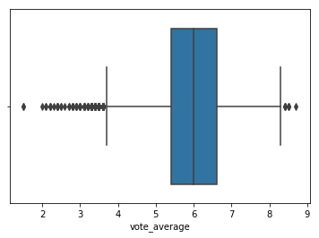

```python
sns.boxplot(df['vote_average'])
```

```
Text(0.5,1,'Distribution of Vote average')
```

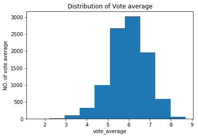

```python
plt.hist(df['vote_average'])
plt.xlabel('vote_average')
plt.ylabel('NO. of vote average')
plt.title("Distribution of Vote average")
```

it seems that the vote average slightly skewed to the left, with mean of 5.9

### Which movie has the shortest/longest runtime?

```python
#first, let's see the distribution of run time
df['runtime'].mean()
```

```
103.06373603852853
```

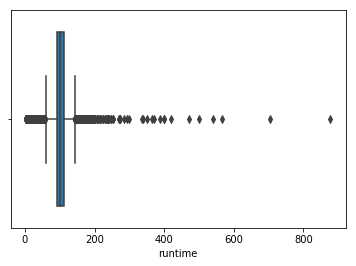

```python
sns.boxplot(df['runtime'])
```

it seemed like there are alot of outliers in our dataset according to the run time

```python
#Make function to find min and max
def minmax(x):
    #use the function 'idmin' to find the index of lowest profit movie.
    min_movie = df[x].idxmin()
    #use the function 'idmax' to find the index of Highest profit movie.
    max_movie = df[x].idxmax()
    high = pd.DataFrame(df.loc[max_movie,:])
    low = pd.DataFrame(df.loc[min_movie,:])
    print("Movie Which Has Highest "+ x + " : ",df['original_title'][max_movie])
    print("Movie Which Has Lowest "+ x + "  : ",df['original_title'][min_movie])
    return pd.concat([high,low],axis = 1)
#find the movie with the most runtime
minmax('runtime')
```

```
Movie Which Has Highest runtime :  Taken
Movie Which Has Lowest runtime  :  Batman: Strange Days
```

|  | 4041 | 1112 |
| --- | --- | --- |
| id | 150004 | 264170 |
| popularity | 0.469332 | 0.202776 |
| original_title | Taken | Batman: Strange Days |
| cast | Dakota Fanning\|Matt Frewer\|Eric Close\|Emily Be... | Kevin Conroy\|Brian George\|Tara Strong |
| director | Breck Eisner\|Félix Enríquez Alcalá\|John Faw... | Bruce Timm |
| runtime | 877 | 3 |
| genres | Science Fiction | Action\|Animation |
| production_companies | DreamWorks | DC Comics |
| vote_count | 38 | 20 |
| vote_average | 6.8 | 7.6 |
| release_year | 2002 | 2014 |
| budget | 0 | 0 |
| revenue | 0 | 0 |

It seems that there is 1 movie(Taken) with the most run time(877 min.)

### Which year has the most/least movies released?

```python
(df.groupby('release_year')['id'].count().idxmax(),df.groupby('release_year')['id'].count().max())
```

```
(2014, 633)
```

```python
(df.groupby('release_year')['id'].count().idxmin(),df.groupby('release_year')['id'].count().min())
```

```
(1969, 29)
```

```
Text(0.5,1,'NO. of movies across th years')
```

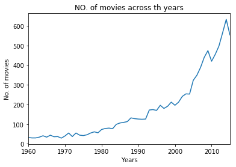

```python
df.groupby('release_year')['id'].count().plot(kind='line')
plt.xlabel('Years')
plt.ylabel('No. of movies')
plt.title('NO. of movies across th years')
```

It seems that the year with most movies realesed is 2014 by 633 movies. wooow!! and the least one is 1969 by 29 movies.

### Which movie has the highest/lowest profit?

```python
#First let's make a profit column
df['profit']=df['revenue']-df['budget']
df.head()
```

|  | id | popularity | original_title | cast | director | runtime | genres | production_companies | vote_count | vote_average | release_year | budget | revenue | profit |
| --- | --- | --- | --- | --- | --- | --- | --- | --- | --- | --- | --- | --- | --- | --- |
| 0 | 135397 | 32.985763 | Jurassic World | Chris Pratt\|Bryce Dallas Howard\|Irrfan Khan\|Vi... | Colin Trevorrow | 124.0 | Action\|Adventure\|Science Fiction\|Thriller | Universal Studios\|Amblin Entertainment\|Legenda... | 5562 | 6.5 | 2015 | 1.379999e+08 | 1.392446e+09 | 1.254446e+09 |
| 1 | 76341 | 28.419936 | Mad Max: Fury Road | Tom Hardy\|Charlize Theron\|Hugh Keays-Byrne\|Nic... | George Miller | 120.0 | Action\|Adventure\|Science Fiction\|Thriller | Village Roadshow Pictures\|Kennedy Miller Produ... | 6185 | 7.1 | 2015 | 1.379999e+08 | 3.481613e+08 | 2.101614e+08 |
| 2 | 262500 | 13.112507 | Insurgent | Shailene Woodley\|Theo James\|Kate Winslet\|Ansel... | Robert Schwentke | 119.0 | Adventure\|Science Fiction\|Thriller | Summit Entertainment\|Mandeville Films\|Red Wago... | 2480 | 6.3 | 2015 | 1.012000e+08 | 2.716190e+08 | 1.704191e+08 |
| 3 | 140607 | 11.173104 | Star Wars: The Force Awakens | Harrison Ford\|Mark Hamill\|Carrie Fisher\|Adam D... | J.J. Abrams | 136.0 | Action\|Adventure\|Science Fiction\|Fantasy | Lucasfilm\|Truenorth Productions\|Bad Robot | 5292 | 7.5 | 2015 | 1.839999e+08 | 1.902723e+09 | 1.718723e+09 |
| 4 | 168259 | 9.335014 | Furious 7 | Vin Diesel\|Paul Walker\|Jason Statham\|Michelle ... | James Wan | 137.0 | Action\|Crime\|Thriller | Universal Pictures\|Original Film\|Media Rights ... | 2947 | 7.3 | 2015 | 1.747999e+08 | 1.385749e+09 | 1.210949e+09 |

```python
#The movie with the highest/lowest profit
minmax('profit')
```

```
Movie Which Has Highest profit :  Star Wars
Movie Which Has Lowest profit  :  The Warrior's Way
```

|  | 1329 | 2244 |
| --- | --- | --- |
| id | 11 | 46528 |
| popularity | 12.0379 | 0.25054 |
| original_title | Star Wars | The Warrior's Way |
| cast | Mark Hamill\|Harrison Ford\|Carrie Fisher\|Peter ... | Kate Bosworth\|Jang Dong-gun\|Geoffrey Rush\|Dann... |
| director | George Lucas | Sngmoo Lee |
| runtime | 121 | 100 |
| genres | Adventure\|Action\|Science Fiction | Adventure\|Fantasy\|Action\|Western\|Thriller |
| production_companies | Lucasfilm\|Twentieth Century Fox Film Corporation | Boram Entertainment Inc. |
| vote_count | 4428 | 74 |
| vote_average | 7.9 | 6.4 |
| release_year | 1977 | 2010 |
| budget | 3.95756e+07 | 4.25e+08 |
| revenue | 2.78971e+09 | 1.10876e+07 |
| profit | 2.75014e+09 | -4.13912e+08 |

### Most Frequent movie director?

```python
df['director'].value_counts()
```

```
Woody Allen               42
Clint Eastwood            34
Steven Spielberg          29
Martin Scorsese           26
Ridley Scott              23
                          ..
Dan Bradley                1
Jez Butterworth            1
Joan Micklin Silver        1
Nicholas Ray|Guy Green     1
Rick Jacobson              1
Name: director, Length: 4497, dtype: int64
```

It seems that Woody Allen has 42 movies in our dataset

```python
#let's see the directors with the most profit
df.groupby('director')['profit'].sum().sort_values()
```

```
director
Sngmoo Lee          -4.139124e+08
Uwe Boll            -1.604369e+08
Sergey Bondarchuk   -1.404092e+08
Roland JoffÃ©       -1.319827e+08
Sam Weisman         -1.232507e+08
                         ...
Chris Columbus       4.353343e+09
Peter Jackson        5.644123e+09
George Lucas         5.844159e+09
James Cameron        6.296229e+09
Steven Spielberg     1.305068e+10
Name: profit, Length: 4497, dtype: float64
```

Despite Woody Allen has 42 movies in our dataset but he doesn't appear in the most profit directors

### What is production company with the most profit?

```python
df.groupby('production_companies')['profit'].sum().sort_values()
```

```
production_companies
Boram Entertainment Inc.                                                                                             -4.139124e+08
Columbia Pictures|Revolution Studios                                                                                 -2.064243e+08
Caravan Pictures|Touchstone Pictures                                                                                 -1.777232e+08
Walt Disney Pictures|Jerry Bruckheimer Films|Infinitum Nihil|Silver Bullet Productions (II)|Blind Wink Productions   -1.551102e+08
Universal Pictures|Stuber Productions|Relativity Media                                                               -1.500000e+08
                                                                                                                          ...
DreamWorks Animation                                                                                                  4.561637e+09
Lucasfilm|Twentieth Century Fox Film Corporation                                                                      5.310129e+09
Universal Pictures                                                                                                    5.644353e+09
Walt Disney Pictures|Pixar Animation Studios                                                                          6.328198e+09
Paramount Pictures                                                                                                    1.119874e+10
Name: profit, Length: 7398, dtype: float64
```

It seems that Paramount Pictures outperforms Walt Disney Pictures|Pixar Animation Studios and take the first place.

### Does the production company affects on movie's popularity?

```python
df.groupby('production_companies')['popularity'].mean().sort_values()
```

```
production_companies
Simcha Productions                                                                                                0.000188
School Pictures|Parting Shots Media|Logolite Entertainment                                                        0.000620
RhÃ´ne-Alpes CinÃ©ma|France2 CinÃ©ma                                                                              0.000973
Canal+|Chain Camera Pictures|ITVS|Rise Films|Girls' Club Entertainment                                            0.001372
Bronson Avenue|Paramount Pictures Digital Entertainment|Mountain Dew Green Label Studios|Milchan / Van Eyssen     0.001423
                                                                                                                   ...
Summit Entertainment|Mandeville Films|Red Wagon Entertainment|NeoReel                                            13.112507
Marvel Studios|Moving Picture Company (MPC)|Bulletproof Cupid|Revolution Sun Studios                             14.311205
Paramount Pictures|Legendary Pictures|Warner Bros.|Syncopy|Lynda Obst Productions                                24.949134
Village Roadshow Pictures|Kennedy Miller Productions                                                             28.419936
Universal Studios|Amblin Entertainment|Legendary Pictures|Fuji Television Network|Dentsu                         32.985763
Name: popularity, Length: 7398, dtype: float64
```

### The relationship between vote average and revenue

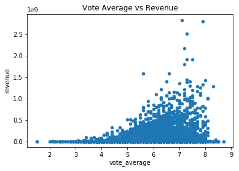

```python
df.plot(x='vote_average',y='revenue',kind='scatter')
plt.title('Vote Average vs Revenue')
plt.show()
```

The plot indicates a positive relationship between vote average and revenue.

### The relationship between vote average and budget

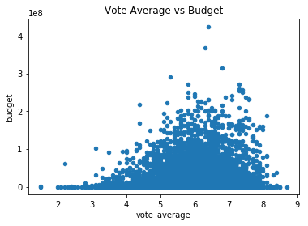

```python
df.plot(x='vote_average',y='budget',kind='scatter')
plt.title('Vote Average vs Budget')
plt.show()
```

### Which genres are most popular from year to year?

```python
#We have to split genres for the movies
dummies = df['genres'].str.get_dummies(sep='|')
df = pd.concat([df, dummies], axis=1)
```

Here I used get_dummies function to separate generes and give 1 for used genre and 0 for the unused, then i concate it with the original dataset.

```python
df.head()
```

|  | id | popularity | original_title | cast | director | runtime | genres | production_companies | vote_count | vote_average | ... | History | Horror | Music | Mystery | Romance | Science Fiction | TV Movie | Thriller | War | Western |
| --- | --- | --- | --- | --- | --- | --- | --- | --- | --- | --- | --- | --- | --- | --- | --- | --- | --- | --- | --- | --- | --- |
| 0 | 135397 | 32.985763 | Jurassic World | Chris Pratt\|Bryce Dallas Howard\|Irrfan Khan\|Vi... | Colin Trevorrow | 124.0 | Action\|Adventure\|Science Fiction\|Thriller | Universal Studios\|Amblin Entertainment\|Legenda... | 5562 | 6.5 | ... | 0 | 0 | 0 | 0 | 0 | 1 | 0 | 1 | 0 | 0 |
| 1 | 76341 | 28.419936 | Mad Max: Fury Road | Tom Hardy\|Charlize Theron\|Hugh Keays-Byrne\|Nic... | George Miller | 120.0 | Action\|Adventure\|Science Fiction\|Thriller | Village Roadshow Pictures\|Kennedy Miller Produ... | 6185 | 7.1 | ... | 0 | 0 | 0 | 0 | 0 | 1 | 0 | 1 | 0 | 0 |
| 2 | 262500 | 13.112507 | Insurgent | Shailene Woodley\|Theo James\|Kate Winslet\|Ansel... | Robert Schwentke | 119.0 | Adventure\|Science Fiction\|Thriller | Summit Entertainment\|Mandeville Films\|Red Wago... | 2480 | 6.3 | ... | 0 | 0 | 0 | 0 | 0 | 1 | 0 | 1 | 0 | 0 |
| 3 | 140607 | 11.173104 | Star Wars: The Force Awakens | Harrison Ford\|Mark Hamill\|Carrie Fisher\|Adam D... | J.J. Abrams | 136.0 | Action\|Adventure\|Science Fiction\|Fantasy | Lucasfilm\|Truenorth Productions\|Bad Robot | 5292 | 7.5 | ... | 0 | 0 | 0 | 0 | 0 | 1 | 0 | 0 | 0 | 0 |
| 4 | 168259 | 9.335014 | Furious 7 | Vin Diesel\|Paul Walker\|Jason Statham\|Michelle ... | James Wan | 137.0 | Action\|Crime\|Thriller | Universal Pictures\|Original Film\|Media Rights ... | 2947 | 7.3 | ... | 0 | 0 | 0 | 0 | 0 | 0 | 0 | 1 | 0 | 0 |

5 rows × 34 columns

```python
#we don't want (genres)column any more, let' drop it
df.drop(columns='genres',inplace=True)
```

```python
#Make a list with the genres
genres=['Action', 'Adventure', 'Animation',
       'Comedy', 'Crime', 'Documentary', 'Drama', 'Family', 'Fantasy',
       'Foreign', 'History', 'Horror', 'Music', 'Mystery', 'Romance',
       'Science Fiction', 'TV Movie', 'Thriller', 'War', 'Western']
```

```python
#See Which genres are most popular from year to year
df.groupby('release_year')[genres].sum()
```

| release_year | Action | Adventure | Animation | Comedy | Crime | Documentary | Drama | Family | Fantasy | Foreign | History | Horror | Music | Mystery | Romance | Science Fiction | TV Movie | Thriller | War | Western |
| --- | --- | --- | --- | --- | --- | --- | --- | --- | --- | --- | --- | --- | --- | --- | --- | --- | --- | --- | --- | --- |
| 1960 | 8 | 5 | 0 | 8 | 2 | 0 | 13 | 3 | 2 | 1 | 5 | 7 | 1 | 0 | 6 | 3 | 0 | 6 | 2 | 6 |
| 1961 | 7 | 6 | 1 | 10 | 2 | 0 | 16 | 4 | 1 | 1 | 3 | 3 | 2 | 1 | 7 | 3 | 0 | 0 | 2 | 3 |
| 1962 | 6 | 7 | 0 | 5 | 3 | 0 | 19 | 2 | 1 | 1 | 3 | 5 | 1 | 4 | 5 | 2 | 0 | 7 | 2 | 3 |
| 1963 | 4 | 7 | 1 | 13 | 4 | 0 | 13 | 3 | 2 | 2 | 4 | 9 | 0 | 6 | 8 | 2 | 0 | 10 | 1 | 2 |
| 1964 | 5 | 5 | 2 | 16 | 10 | 0 | 20 | 4 | 3 | 1 | 3 | 6 | 5 | 4 | 9 | 4 | 0 | 9 | 3 | 1 |
| 1965 | 9 | 6 | 1 | 7 | 2 | 0 | 19 | 3 | 0 | 0 | 4 | 4 | 2 | 3 | 5 | 1 | 1 | 10 | 8 | 4 |
| 1966 | 14 | 11 | 2 | 15 | 5 | 1 | 15 | 6 | 2 | 2 | 2 | 3 | 0 | 6 | 5 | 6 | 0 | 8 | 4 | 7 |
| 1967 | 6 | 6 | 1 | 16 | 7 | 1 | 16 | 3 | 3 | 0 | 0 | 4 | 4 | 3 | 11 | 3 | 0 | 5 | 1 | 2 |
| 1968 | 6 | 5 | 3 | 8 | 5 | 0 | 19 | 5 | 5 | 0 | 3 | 4 | 3 | 4 | 6 | 4 | 0 | 5 | 4 | 1 |
| 1969 | 10 | 5 | 2 | 10 | 3 | 0 | 13 | 4 | 2 | 0 | 3 | 1 | 2 | 1 | 3 | 3 | 1 | 3 | 3 | 7 |
| 1970 | 11 | 6 | 2 | 12 | 4 | 3 | 19 | 3 | 3 | 1 | 3 | 5 | 4 | 3 | 6 | 3 | 1 | 5 | 5 | 8 |
| 1971 | 11 | 5 | 1 | 9 | 10 | 0 | 30 | 2 | 2 | 0 | 3 | 7 | 1 | 6 | 9 | 6 | 1 | 17 | 4 | 5 |
| 1972 | 9 | 5 | 1 | 13 | 6 | 0 | 16 | 1 | 1 | 0 | 0 | 8 | 1 | 4 | 5 | 4 | 0 | 10 | 0 | 5 |
| 1973 | 15 | 5 | 3 | 8 | 17 | 1 | 31 | 4 | 1 | 0 | 2 | 15 | 1 | 7 | 3 | 6 | 1 | 16 | 0 | 4 |
| 1974 | 14 | 7 | 1 | 11 | 15 | 1 | 21 | 3 | 3 | 0 | 1 | 8 | 1 | 5 | 3 | 5 | 1 | 20 | 1 | 2 |
| 1975 | 9 | 8 | 1 | 11 | 6 | 1 | 17 | 2 | 4 | 0 | 3 | 8 | 3 | 8 | 2 | 10 | 0 | 12 | 2 | 3 |
| 1976 | 13 | 6 | 0 | 11 | 8 | 1 | 22 | 3 | 2 | 1 | 2 | 9 | 3 | 7 | 5 | 5 | 1 | 17 | 2 | 3 |
| 1977 | 14 | 15 | 5 | 10 | 2 | 1 | 23 | 7 | 9 | 0 | 4 | 14 | 3 | 5 | 4 | 10 | 0 | 12 | 4 | 1 |
| 1978 | 15 | 10 | 2 | 13 | 6 | 2 | 28 | 5 | 4 | 1 | 2 | 19 | 3 | 7 | 5 | 15 | 3 | 22 | 4 | 1 |
| 1979 | 8 | 8 | 1 | 18 | 8 | 0 | 30 | 5 | 0 | 0 | 3 | 11 | 4 | 4 | 8 | 10 | 0 | 16 | 3 | 4 |
| 1980 | 23 | 13 | 0 | 20 | 8 | 0 | 32 | 4 | 6 | 2 | 5 | 16 | 4 | 8 | 9 | 11 | 1 | 24 | 2 | 5 |
| 1981 | 15 | 12 | 3 | 19 | 10 | 1 | 32 | 5 | 3 | 0 | 4 | 24 | 3 | 10 | 10 | 9 | 1 | 26 | 1 | 0 |
| 1982 | 16 | 10 | 6 | 28 | 9 | 1 | 33 | 8 | 13 | 2 | 2 | 20 | 6 | 10 | 12 | 13 | 1 | 17 | 2 | 2 |
| 1983 | 21 | 14 | 3 | 27 | 11 | 0 | 34 | 3 | 10 | 1 | 1 | 12 | 4 | 5 | 14 | 16 | 1 | 24 | 1 | 1 |
| 1984 | 32 | 21 | 0 | 37 | 14 | 1 | 37 | 9 | 15 | 0 | 5 | 18 | 11 | 4 | 19 | 24 | 1 | 22 | 3 | 0 |
| 1985 | 28 | 28 | 2 | 50 | 14 | 1 | 38 | 11 | 13 | 0 | 0 | 14 | 2 | 3 | 21 | 17 | 0 | 24 | 2 | 2 |
| 1986 | 29 | 17 | 5 | 47 | 18 | 0 | 48 | 11 | 9 | 0 | 3 | 25 | 5 | 7 | 24 | 18 | 0 | 22 | 4 | 1 |
| 1987 | 28 | 16 | 2 | 53 | 21 | 0 | 47 | 13 | 17 | 0 | 3 | 23 | 3 | 7 | 21 | 17 | 2 | 27 | 6 | 1 |
| 1988 | 31 | 14 | 4 | 65 | 21 | 1 | 49 | 14 | 14 | 1 | 3 | 34 | 4 | 7 | 19 | 18 | 1 | 32 | 6 | 0 |
| 1989 | 38 | 23 | 3 | 59 | 24 | 2 | 53 | 15 | 14 | 1 | 4 | 25 | 2 | 8 | 22 | 21 | 0 | 35 | 4 | 1 |
| 1990 | 36 | 22 | 4 | 46 | 30 | 0 | 58 | 12 | 13 | 1 | 3 | 25 | 2 | 14 | 18 | 18 | 1 | 45 | 2 | 3 |
| 1991 | 35 | 21 | 3 | 57 | 20 | 3 | 62 | 21 | 17 | 2 | 1 | 11 | 7 | 9 | 26 | 10 | 0 | 35 | 2 | 1 |
| 1992 | 33 | 17 | 4 | 50 | 25 | 0 | 63 | 16 | 13 | 2 | 4 | 16 | 5 | 10 | 30 | 15 | 0 | 45 | 1 | 2 |
| 1993 | 51 | 25 | 6 | 69 | 28 | 0 | 89 | 29 | 13 | 3 | 8 | 17 | 6 | 15 | 33 | 17 | 0 | 45 | 6 | 3 |
| 1994 | 58 | 31 | 8 | 83 | 25 | 2 | 79 | 33 | 23 | 3 | 3 | 13 | 3 | 10 | 34 | 19 | 4 | 42 | 3 | 8 |
| 1995 | 46 | 30 | 6 | 60 | 31 | 1 | 92 | 31 | 17 | 1 | 7 | 19 | 0 | 14 | 37 | 18 | 1 | 48 | 5 | 3 |
| 1996 | 41 | 29 | 8 | 86 | 19 | 2 | 100 | 31 | 21 | 1 | 4 | 17 | 3 | 13 | 43 | 24 | 2 | 61 | 3 | 0 |
| 1997 | 57 | 33 | 8 | 73 | 26 | 1 | 78 | 30 | 18 | 2 | 6 | 18 | 4 | 20 | 30 | 29 | 1 | 59 | 1 | 0 |
| 1998 | 42 | 35 | 14 | 78 | 32 | 2 | 97 | 32 | 20 | 1 | 6 | 20 | 11 | 17 | 38 | 25 | 2 | 51 | 3 | 1 |
| 1999 | 37 | 17 | 13 | 97 | 29 | 4 | 109 | 25 | 20 | 3 | 6 | 24 | 4 | 24 | 42 | 27 | 5 | 51 | 3 | 3 |
| 2000 | 42 | 25 | 22 | 83 | 28 | 3 | 88 | 29 | 19 | 3 | 4 | 18 | 9 | 13 | 41 | 24 | 1 | 56 | 4 | 2 |
| 2001 | 58 | 35 | 15 | 89 | 37 | 3 | 86 | 22 | 21 | 2 | 10 | 20 | 5 | 21 | 48 | 23 | 6 | 63 | 10 | 2 |
| 2002 | 69 | 42 | 19 | 94 | 39 | 6 | 117 | 33 | 17 | 9 | 8 | 29 | 2 | 26 | 45 | 26 | 2 | 81 | 7 | 1 |
| 2003 | 66 | 37 | 27 | 102 | 45 | 7 | 95 | 39 | 24 | 2 | 9 | 22 | 9 | 17 | 46 | 35 | 2 | 67 | 8 | 3 |
| 2004 | 61 | 40 | 20 | 102 | 28 | 5 | 116 | 31 | 17 | 2 | 7 | 28 | 7 | 25 | 53 | 31 | 3 | 65 | 7 | 7 |
| 2005 | 68 | 51 | 20 | 129 | 43 | 9 | 158 | 49 | 32 | 7 | 9 | 56 | 11 | 29 | 57 | 22 | 2 | 88 | 4 | 2 |
| 2006 | 69 | 52 | 31 | 137 | 50 | 11 | 177 | 52 | 30 | 5 | 12 | 48 | 11 | 30 | 62 | 26 | 8 | 100 | 7 | 1 |
| 2007 | 89 | 56 | 29 | 133 | 64 | 8 | 180 | 40 | 45 | 10 | 12 | 76 | 13 | 32 | 65 | 34 | 4 | 117 | 6 | 5 |
| 2008 | 88 | 58 | 30 | 146 | 57 | 20 | 211 | 48 | 38 | 14 | 21 | 71 | 15 | 27 | 76 | 47 | 5 | 118 | 17 | 2 |
| 2009 | 97 | 67 | 45 | 180 | 52 | 13 | 199 | 52 | 46 | 9 | 14 | 85 | 14 | 49 | 74 | 65 | 7 | 145 | 11 | 0 |
| 2010 | 99 | 57 | 46 | 149 | 46 | 19 | 189 | 48 | 40 | 9 | 12 | 67 | 5 | 30 | 75 | 42 | 6 | 123 | 7 | 6 |
| 2011 | 105 | 56 | 36 | 147 | 45 | 27 | 185 | 61 | 38 | 7 | 8 | 67 | 12 | 34 | 62 | 50 | 9 | 133 | 9 | 3 |
| 2012 | 96 | 49 | 35 | 150 | 52 | 28 | 202 | 39 | 32 | 4 | 11 | 92 | 14 | 27 | 70 | 50 | 9 | 148 | 9 | 3 |
| 2013 | 110 | 61 | 39 | 150 | 67 | 39 | 228 | 44 | 35 | 0 | 11 | 90 | 23 | 36 | 56 | 50 | 9 | 165 | 7 | 3 |
| 2014 | 124 | 66 | 34 | 167 | 59 | 46 | 269 | 41 | 35 | 0 | 14 | 97 | 24 | 34 | 76 | 57 | 11 | 170 | 22 | 5 |
| 2015 | 102 | 65 | 37 | 143 | 47 | 37 | 232 | 41 | 31 | 0 | 13 | 114 | 31 | 39 | 45 | 82 | 12 | 160 | 8 | 6 |

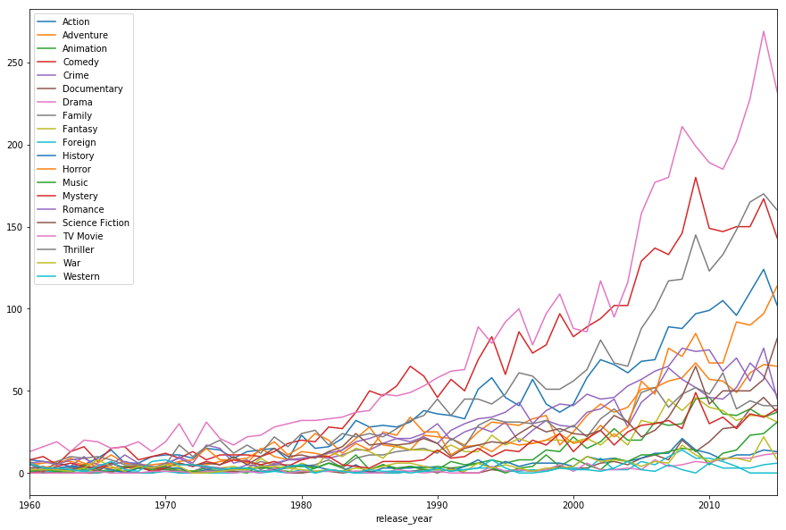

```python
plt.rcParams["figure.figsize"] = (15,10)
df.groupby('release_year')[genres].sum().plot(kind='line')
```

```python
df.groupby('release_year')[genres].sum().idxmax(axis=1)
```

```
release_year
1960     Drama
1961     Drama
1962     Drama
1963    Comedy
1964     Drama
1965     Drama
1966    Comedy
1967    Comedy
1968     Drama
1969     Drama
1970     Drama
1971     Drama
1972     Drama
1973     Drama
```

[output cut: 43 more lines]

As we noticed before Drama out perform all other genres but also there are some year that Comedy out perform Drama

## Conclusions

In this analysis, I was able to analyze these qualities and identify which properties are associated with movie popularity.

I cleaned the dataset by removing duplicates, nans, and unneeded columns.

I plotted a few charts to assess what will be used as the dependent variable.

I found that Drama is the most popular genre throw the years

Maximum Number Of Movies Release In year 2014.

#### Limitations

This analysis require deeper statistical analysis that was not performed in this project.

```python
from subprocess import call
call(['python', '-m', 'nbconvert', 'Investigate_a_Dataset.ipynb'])
```

```
0
```